# Assignment 2

2024-10-15

## FA 582-A Foundation of Financial Data Science

## PROBLEM 1:

Write an R code to scrape the website: https://en.wikipedia.org/wiki/List_of_S%26P_500_companies

Retrieve the content of the S&P 500 component stocks table (Symbol, Security, GISC Sector, GICS Sub- Industry, Headquarters Location, Date added, CIK, Founded). Create an R dataframe and perform exploratory data analysis and report summary statistics.

```
## # A tibble: 6 × 8
##   Symbol Security GICS_Sector GICS_Sub_Industry Headquarters_Location Date_added
##   <chr>  <chr>    <fct>       <fct>             <chr>                 <date>
## 1 MMM    3M       Industrials Industrial Congl… Saint Paul, Minnesota 1957-03-04
## 2 AOS    A. O. S… Industrials Building Products Milwaukee, Wisconsin  2017-07-26
## 3 ABT    Abbott … Health Care Health Care Equi… North Chicago, Illin… 1957-03-04
## 4 ABBV   AbbVie   Health Care Biotechnology     North Chicago, Illin… 2012-12-31
## 5 ACN    Accentu… Informatio… IT Consulting & … Dublin, Ireland       2011-07-06
## 6 ADBE   Adobe I… Informatio… Application Soft… San Jose, California  1997-05-05
## # ℹ 2 more variables: CIK <chr>, Founded <chr>
```

## Perform exploratory data analysis and report summary statistics

# 1. Summary Statistics for the Dataset

```
##         Min.      1st Qu.       Median         Mean      3rd Qu.         Max.
## "1957-03-04" "1993-02-28" "2008-03-31" "2001-07-14" "2017-03-20" "2024-09-30"
```

```
## Communication Services Consumer Discretionary       Consumer Staples
##                     22                     50                     38
##                 Energy             Financials            Health Care
##                     22                     72                     62
##            Industrials Information Technology              Materials
##                     78                     69                     28
##            Real Estate              Utilities
##                     31                     31
```

```
##                                   Health Care Equipment
##                                                      18
##                                      Electric Utilities
##                                                      15
##                                          Semiconductors
##                                                      15
##            Industrial Machinery & Supplies & Components
##                                                      14
##                                     Aerospace & Defense
##                                                      12
##                                         Multi-Utilities
##                                                      12
##                                  Packaged Foods & Meats
##                                                      12
##                                    Application Software
##                                                      11
##                        Asset Management & Custody Banks
##                                                      10
##                              Financial Exchanges & Data
##                                                       9
##                      Oil & Gas Exploration & Production
##                                                       9
##                                     Specialty Chemicals
##                                                       9
##                                           Biotechnology
##                                                       8
##                          Hotels, Resorts & Cruise Lines
##                                                       8
##                          Life Sciences Tools & Services
##                                                       8
##                                         Pharmaceuticals
##                                                       8
##                           Property & Casualty Insurance
##                                                       8
##              Technology Hardware, Storage & Peripherals
##                                                       8
##               Transaction & Payment Processing Services
##                                                       8
##                                       Building Products
##                                                       7
```

[output cut: 145 more lines]

```
##                                                       2
##                                    Real Estate Services
##                                                       2
##                          Research & Consulting Services
##                                                       2
##                                      Self-Storage REITs
##                                                       2
##                                                   Steel
##                                                       2
##                                                 Tobacco
##                                                       2
##                        Trading Companies & Distributors
##                                                       2
##                                                 (Other)
##                                                      28
```

```
##    Length     Class      Mode
##       503 character character
```

# 2. Distribution of Companies by Sector (GICS_Sector)

```
## # A tibble: 11 × 2
##    GICS_Sector            Count
##    <fct>                  <int>
##  1 Industrials               78
##  2 Financials                72
##  3 Information Technology    69
##  4 Health Care               62
##  5 Consumer Discretionary    50
##  6 Consumer Staples          38
##  7 Real Estate               31
##  8 Utilities                 31
##  9 Materials                 28
## 10 Communication Services    22
## 11 Energy                    22
```

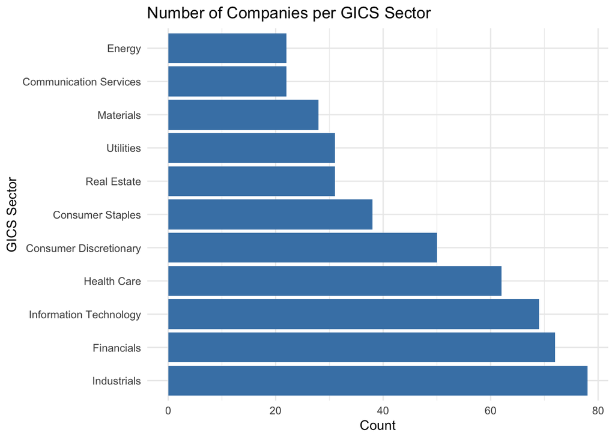

# 3. Distribution of Companies by Sub-Industry (GICS_Sub_Industry)

```
## # A tibble: 127 × 2
##    GICS_Sub_Industry                            Count
##    <fct>                                        <int>
##  1 Health Care Equipment                           18
##  2 Electric Utilities                              15
##  3 Semiconductors                                  15
##  4 Industrial Machinery & Supplies & Components    14
##  5 Aerospace & Defense                             12
##  6 Multi-Utilities                                 12
##  7 Packaged Foods & Meats                          12
##  8 Application Software                            11
##  9 Asset Management & Custody Banks                10
## 10 Financial Exchanges & Data                       9
## # ℹ 117 more rows
```

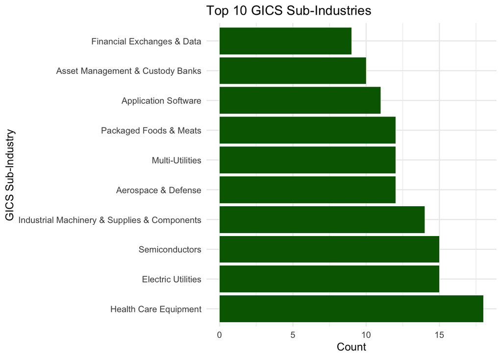

# 4. Distribution of Companies by Headquarters Location

```
## # A tibble: 10 × 2
##    Headquarters_Location     Count
##    <chr>                     <int>
##  1 New York City, New York      40
##  2 Houston, Texas               20
##  3 Chicago, Illinois            16
##  4 Atlanta, Georgia             14
##  5 Dallas, Texas                 9
##  6 Dublin, Ireland               9
##  7 San Jose, California          8
##  8 Santa Clara, California       8
##  9 Irving, Texas                 7
## 10 San Francisco, California     7
```

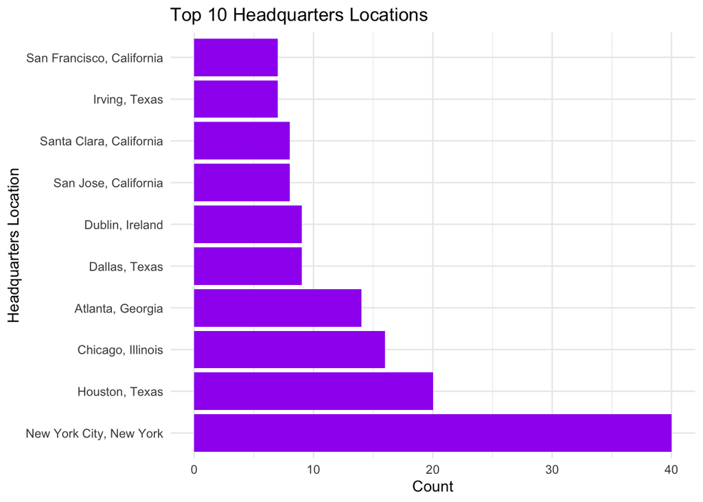

# 5. Analysis of the Founded Column

```
##    Min. 1st Qu.  Median    Mean 3rd Qu.    Max.
##    1784    1920    1971    1956    1994    2024
```

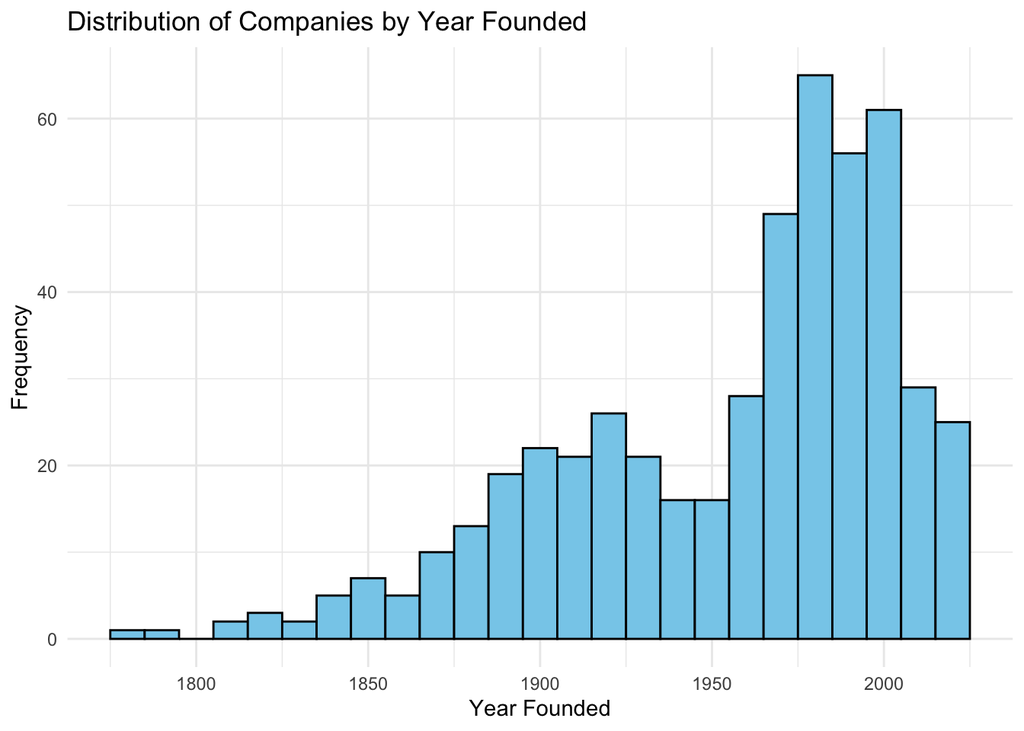

# 6. Correlation between Date Added and Founded Year

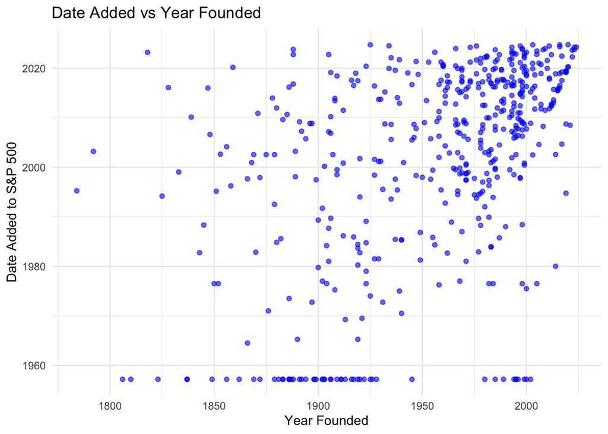

## PROBLEM 2

The data provided in the files contains several quantitative and categorical variables associate with each ticker. Please select a subset of 100 tickers from each file and use data for a specific year (ex: 2013). Use a small number of quantitative variables (10 or 12) out of ~76 columns available (example: After Tax ROE, Cash Ratio, Current Ratio, Operating Margin, Pre-Tax Margin, Pre-Tax ROE, Profit Margin, Quick Ratio, Total Assets, Total Liabilities, Earnings Per Share, etc…). The categorical variables available are GICS Sector, GICS Sub Industry, and possibly HQ Address (although this is sparse data for the 100 tickers subset selected).

Next, caclulate several distance and similarity functions to find the extreme values for distance and similarities between the subset of tickers that you chose. For each of the following cases, please define the function that allows you to calculate the quantity required, calculate the values for all ticker pairs, and rank the pairs by calculated value of distance or similarity, and report the top and bottom 10 values along with the ticker pairs for the following cases:

1. Lp-norm for p= 1
2. Lp-norm for p= 2
3. Lp-norm for p= 3
4. Lp-norm for p= 10
5. Minkovski distance (assign different weights for the feature components in the Lp-norm based on your assessment on the importance of the features)
6. Match-Based Similarity Computation (use a small number of equi-depth buckets, ex: 3)
7. Mahalanobis distance
8. Similarity: overlap measure
9. Similarity: inverse frequency
10. Similarity: Goodall
11. Overall similarity between tickers by using mixed type data (choose a 𝜆𝜆 value for calculation)
12. Overall normalized similarity between tickers by using mixed type data (choose a 𝜆𝜆 value for calculation)

## Lp-Norm Distance Calculations

```
## $L1_Top10
##      Ticker1 Ticker2 L_1_Distance
## 2998    XRAY    CTXS     0.810748
## 154     JNPR    ADBE     1.130156
## 4652    JBHT     HBI     1.239963
## 7591      UA     PKI     1.263059
## 3990     TXT    EXPE     1.396621
## 4671     NWL     HBI     1.397882
## 6598    XRAY     MKC     1.492327
## 6800     ZBH     MOS     1.501762
## 4244     FMC     FLS     1.552745
## 4666     MKC     HBI     1.560527
##
## $L1_Bottom10
##      Ticker1 Ticker2 L_1_Distance
```

[output cut: 88 more lines]

## Weighted Minkowski Distance Function

```
## $Weighted_Minkowski_Top10
##      Ticker1 Ticker2 L_2_Distance
## 2998    XRAY    CTXS   0.09184355
## 154     JNPR    ADBE   0.12269231
## 4652    JBHT     HBI   0.14336763
## 1190     TXT     AVY   0.14783813
## 7591      UA     PKI   0.15292947
## 3990     TXT    EXPE   0.15756020
## 6598    XRAY     MKC   0.16067515
## 4666     MKC     HBI   0.17187617
## 1140    EXPE     AVY   0.17797632
## 3575     PEG      ES   0.18279811
##
## $Weighted_Minkowski_Bottom10
##      Ticker1 Ticker2 L_2_Distance
## 8095    WYNN    SBUX     3.942003
## 4961    LRCX     IBM     3.962234
## 2795    WYNN    COST     3.963329
## 8195    WYNN    SCHW     3.969670
## 1495    WYNN     CAH     4.089041
## 2295    WYNN     CME     4.107780
## 2895    WYNN    CSCO     4.120315
## 8395    WYNN     STT     4.299603
## 4995    WYNN     IBM     4.612449
## 7695    WYNN     PNC     4.655373
```

## Match-Based Similarity Computation (using equi-depth buckets)

```
## $Match_Based_Top10
##     Ticker1 Ticker2 Match_Based_Similarity
## 11     ATVI    ABBV                      1
## 67      MON    ABBV                      1
## 151     IFF    ADBE                      1
## 153     JEC    ADBE                      1
## 154    JNPR    ADBE                      1
## 161    LRCX    ADBE                      1
## 170     NKE    ADBE                      1
## 179     PWR    ADBE                      1
## 186     SYK    ADBE                      1
## 191      UA    ADBE                      1
##
## $Match_Based_Bottom10
##      Ticker1 Ticker2 Match_Based_Similarity
## 4961    LRCX     IBM             0.16666667
## 4962     LYB     IBM             0.16666667
## 4970     NKE     IBM             0.16666667
## 4974     PBI     IBM             0.16666667
## 4979     PWR     IBM             0.16666667
## 4985     STX     IBM             0.16666667
## 4986     SYK     IBM             0.16666667
## 4991      UA     IBM             0.16666667
## 4999    YHOO     IBM             0.16666667
## 4995    WYNN     IBM             0.08333333
```

## Mahalanobis Distance

```
## $Mahalanobis_Top10
##      Ticker1 Ticker2 Mahalanobis_Distance
## 154     JNPR    ADBE            0.4252010
## 2998    XRAY    CTXS            0.5539442
## 6598    XRAY     MKC            0.5755452
## 1844     FMC     CHD            0.6125052
## 3597     XEL      ES            0.6698508
## 3575     PEG      ES            0.6726223
## 1843     FLS     CHD            0.7380431
## 7578     PNR     PKI            0.7883991
## 7591      UA     PKI            0.8062237
## 7098    XRAY     NWL            0.8272711
##
## $Mahalanobis_Bottom10
##      Ticker1 Ticker2 Mahalanobis_Distance
## 2895    WYNN    CSCO             11.36224
## 4964     MAC     IBM             11.37386
## 1450     IBM     CAH             11.44418
## 1495    WYNN     CAH             11.54343
## 4795    WYNN     HCA             11.87530
## 7395    WYNN     PBI             11.93248
## 6395    WYNN     MAC             11.97325
## 4974     PBI     IBM             12.03570
## 7383    SPGI     PBI             12.21535
## 4995    WYNN     IBM             13.05228
```

## Categorical Similarity Calculations

## Similarity: Overlap Measure

```
## $Overlap_Top10
##      Ticker1 Ticker2 Overlap_Similarity
## 1069     FMC      UA          1.0000000
## 225      MHK     AFL          0.6666667
## 286      DHR     AFL          0.6666667
## 518      STX     DPS          0.6666667
## 644      KMB     PEG          0.6666667
## 677      MAA     PEG          0.6666667
## 738     ALXN     LKQ          0.6666667
## 781      AME     LKQ          0.6666667
## 919     ETFC     ZBH          0.6666667
## 923     ADBE     ZBH          0.6666667
##
## $Overlap_Bottom10
##      Ticker1 Ticker2 Overlap_Similarity
## 9597     HBI    CHRW                  0
## 9598    LRCX    CHRW                  0
## 9599    CTXS    CHRW                  0
## 9600       K    CHRW                  0
## 9698    LRCX     HBI                  0
## 9699    CTXS     HBI                  0
## 9700       K     HBI                  0
## 9799    CTXS    LRCX                  0
## 9800       K    LRCX                  0
## 9900       K    CTXS                  0
```

## Similarity: Inverse Frequency Measure

```
## $Inverse_Frequency_Top10
##      Ticker1 Ticker2 Inverse_Frequency_Similarity
## 1131     TXT     FIS                     23.33333
## 3865     LOW     PNR                     23.33333
## 4562     DNB    CELG                     22.22222
## 6691      FE    SPGI                     22.22222
## 2038    ALXN     RRC                     20.37037
## 8084    SYMC     AME                     20.37037
## 225      MHK     AFL                     19.44444
## 286      DHR     AFL                     19.44444
## 2454     XEL     MHK                     19.44444
## 5399    CTXS     XEL                     19.44444
##
## $Inverse_Frequency_Bottom10
##      Ticker1 Ticker2 Inverse_Frequency_Similarity
## 9597     HBI    CHRW                            0
## 9598    LRCX    CHRW                            0
## 9599    CTXS    CHRW                            0
## 9600       K    CHRW                            0
## 9698    LRCX     HBI                            0
## 9699    CTXS     HBI                            0
## 9700       K     HBI                            0
## 9799    CTXS    LRCX                            0
## 9800       K    LRCX                            0
## 9900       K    CTXS                            0
```

## Similarity: Goodall Measure

```
## $Goodall_Top10
##      Ticker1 Ticker2 Goodall_Similarity
## 1069     FMC      UA          0.9964000
## 1131     TXT     FIS          0.6657000
## 3865     LOW     PNR          0.6657000
## 4562     DNB    CELG          0.6653333
## 6691      FE    SPGI          0.6653333
## 644      KMB     PEG          0.6647333
## 677      MAA     PEG          0.6647333
## 4377     MAA     KMB          0.6647333
## 1940      ES     SYY          0.6645000
## 1941     UTX     SYY          0.6645000
##
## $Goodall_Bottom10
##      Ticker1 Ticker2 Goodall_Similarity
## 9597     HBI    CHRW                  0
## 9598    LRCX    CHRW                  0
## 9599    CTXS    CHRW                  0
## 9600       K    CHRW                  0
## 9698    LRCX     HBI                  0
## 9699    CTXS     HBI                  0
## 9700       K     HBI                  0
## 9799    CTXS    LRCX                  0
## 9800       K    LRCX                  0
## 9900       K    CTXS                  0
```

## Overall Similarity between tickers

```
## $Overall_Top10
##      Ticker1 Ticker2 L_2_Distance Overlap_Similarity Overall_Similarity
## 696     JNPR    ADBE    0.4250186          0.0000000          0.7125093
## 442      FLS     CHD    0.8074135          0.3333333          0.7370401
## 1220     NWL    JBHT    0.8182792          0.3333333          0.7424729
## 1835      UA     PKI    0.5297632          0.0000000          0.7648816
## 1470     PWR    JNPR    0.8980906          0.3333333          0.7823786
## 1202     NWL     CNP    0.9173006          0.3333333          0.7919836
## 1700    SYMC     AME    1.2705819          0.6666667          0.8019576
## 1431     PNR     FIS    0.9389977          0.3333333          0.8028322
## 472      FMC     CHD    0.6395224          0.0000000          0.8197612
## 487      FMC     FIS    0.6521161          0.0000000          0.8260580
##
## $Overall_Bottom10
##      Ticker1 Ticker2 L_2_Distance Overlap_Similarity Overall_Similarity
## 1968    WYNN     MAC     13.55248          0.3333333           7.109574
## 2144    YHOO    WYNN     13.24870          0.0000000           7.124352
## 1001     MAA     IBM     13.29707          0.0000000           7.148534
## 1344     PBI     IBM     13.30680          0.0000000           7.153400
## 1122     NFX     IBM     13.34329          0.0000000           7.171643
## 1492     RRC     IBM     13.47351          0.0000000           7.236754
## 1792     TDG     IBM     13.54335          0.0000000           7.271676
## 918     LRCX     IBM     13.72558          0.0000000           7.362791
## 1961    WYNN    COST     13.72937          0.0000000           7.364687
## 1966    WYNN     IBM     15.97799          0.0000000           8.488996
```

## Overall Normalized Similarity between tickers

```
## $Overall_Normalized_Top10
##      Ticker1 Ticker2 L_2_Distance Overlap_Similarity
## 1700    SYMC     AME   0.06024764          0.6666667
## 1106     NFX     CHD   0.08124145          0.6666667
## 1958     WMB      UA   0.08255661          0.6666667
## 1813     TXT     FIS   0.08362447          0.6666667
## 1642     STX     DPS   0.08562882          0.6666667
## 1048     MON     CHD   0.10106202          0.6666667
## 2058     XEL     MHK   0.10831063          0.6666667
## 741        K     DVA   0.12187088          0.6666667
## 506      GIS      CI   0.12327900          0.6666667
## 348      ESS     COL   0.13245361          0.6666667
##      Overall_Normalized_Similarity
## 1700                     0.1967905
## 1106                     0.2072874
```

[output cut: 32 more lines]